# report

### Anexo de mejora de modelo predictivo

Podemos observar que al ajustar una regresión lineal a la variable gross con budget como variable independiente, los residuos no están distribuidos de forma homogénea, así que hay que transformar la variable dependiente para mejorar el ajuste Veamos primero los residuos del modelo creado anteriormente, el normal.

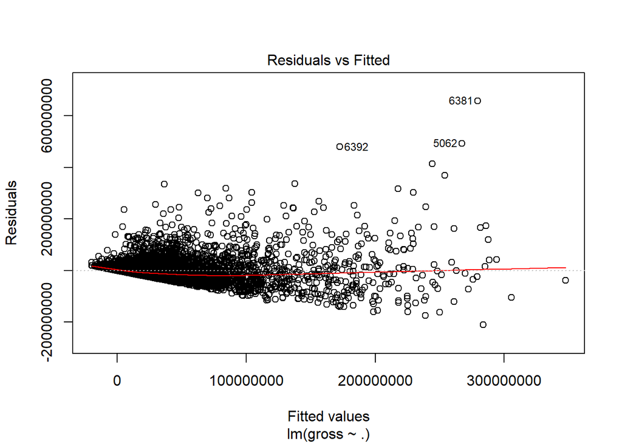

```r
plot(fit,1)
```

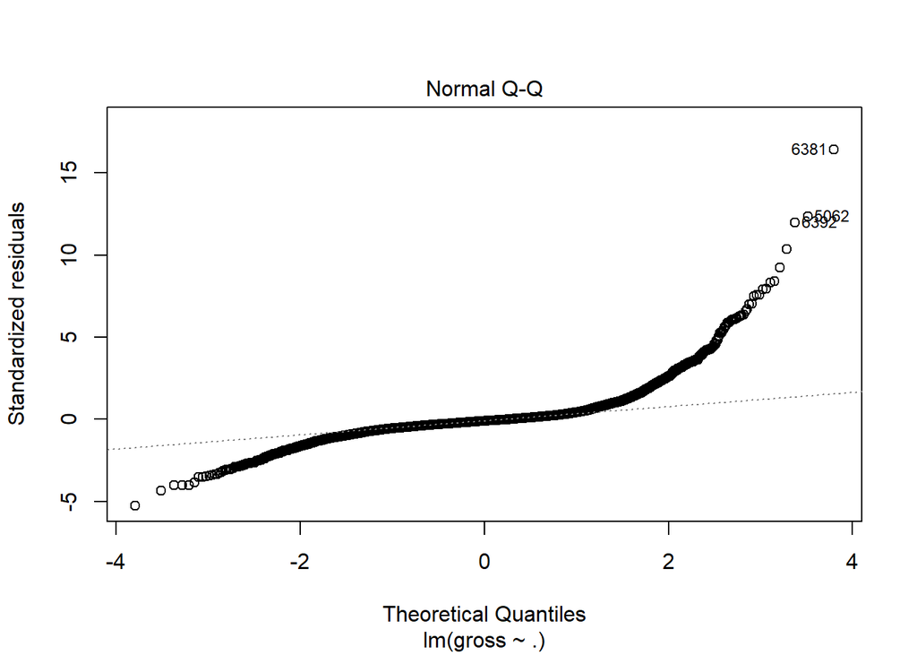

```r
plot(fit,2)
```

En primer lugar vemos la distribución de la variable gross antes de la transformación y después. Vemos que se convierte en una distribución normal. Igual sucede con budget. El modelo de regresión lineal espera que la variable dependiente tenga una distribución normal. Y gracias a esto vemos cómo aumenta la explicabilidad. Conceptualmente lo que está haciendo es que haya más distancia entre los valores pequeños y menos entre los grandes.

```
## [1] "Lambda obtenido para la transformación de la variable dependiente 0.3"
```

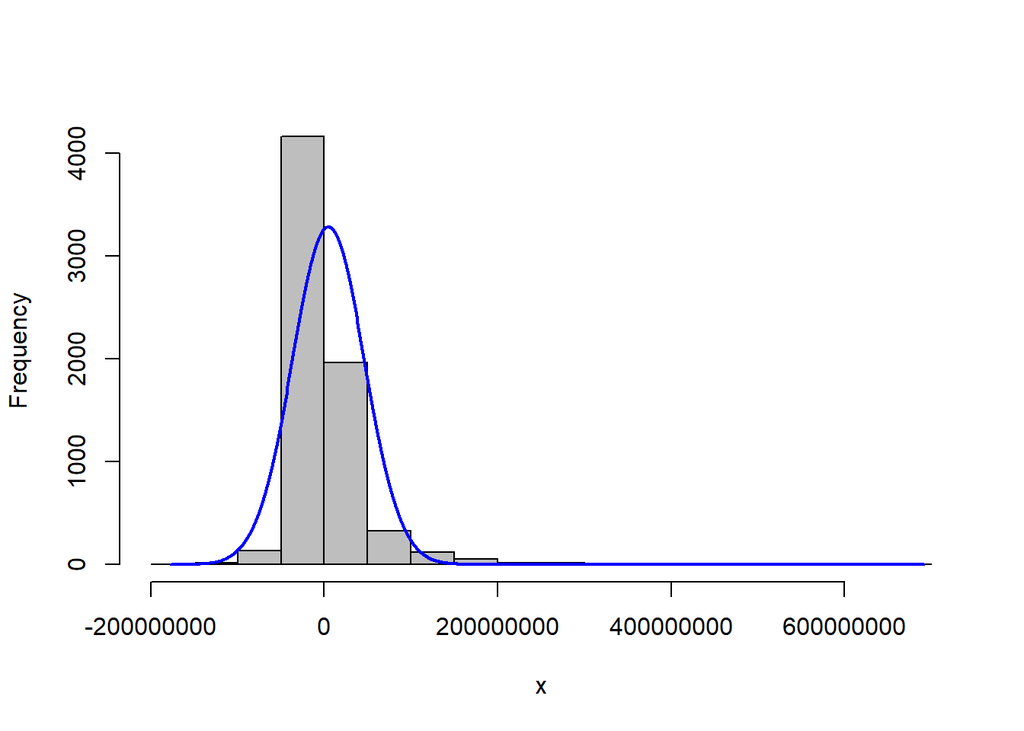

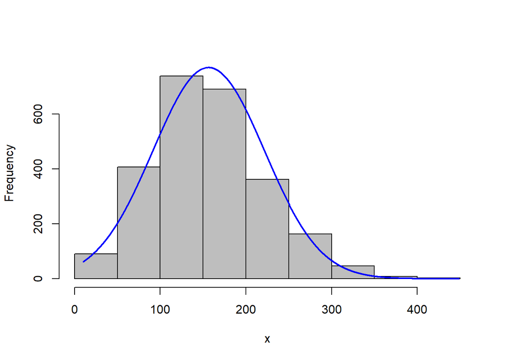

```
## [1] "Lambda obtenido para transformación de la variable dependiente budget 0.2"
```

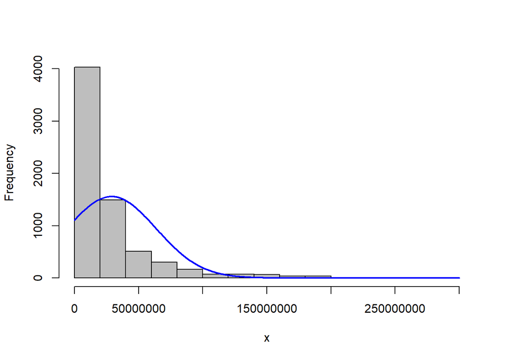

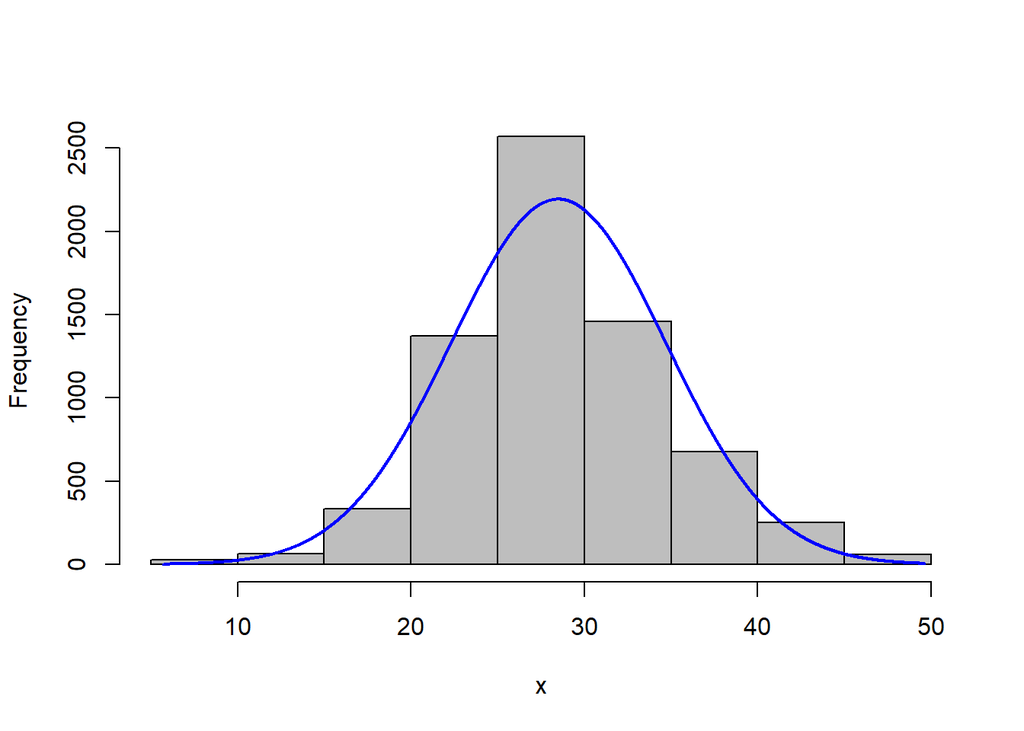

Volvemos a ajustar una regresión lineal con estas variables transformadas y vemos como se cumple la homocedasticidad de los residuos, que es una asunción necesaria para la obtención de un modelo óptimo. Homocedasticidad de los residuos, significa que los errores se repartan igualmente por encima y por debajo.

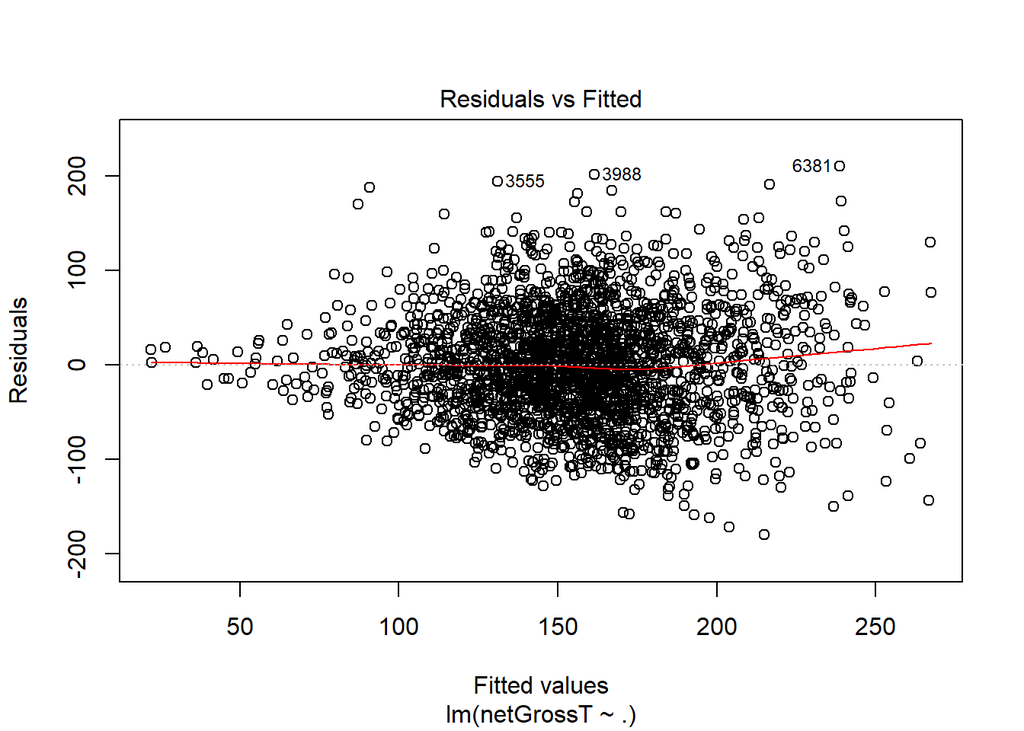

```r
fit.T <- lm(netGrossT ~ ., data=fit.dataT)
plot(fit.T,1)
```

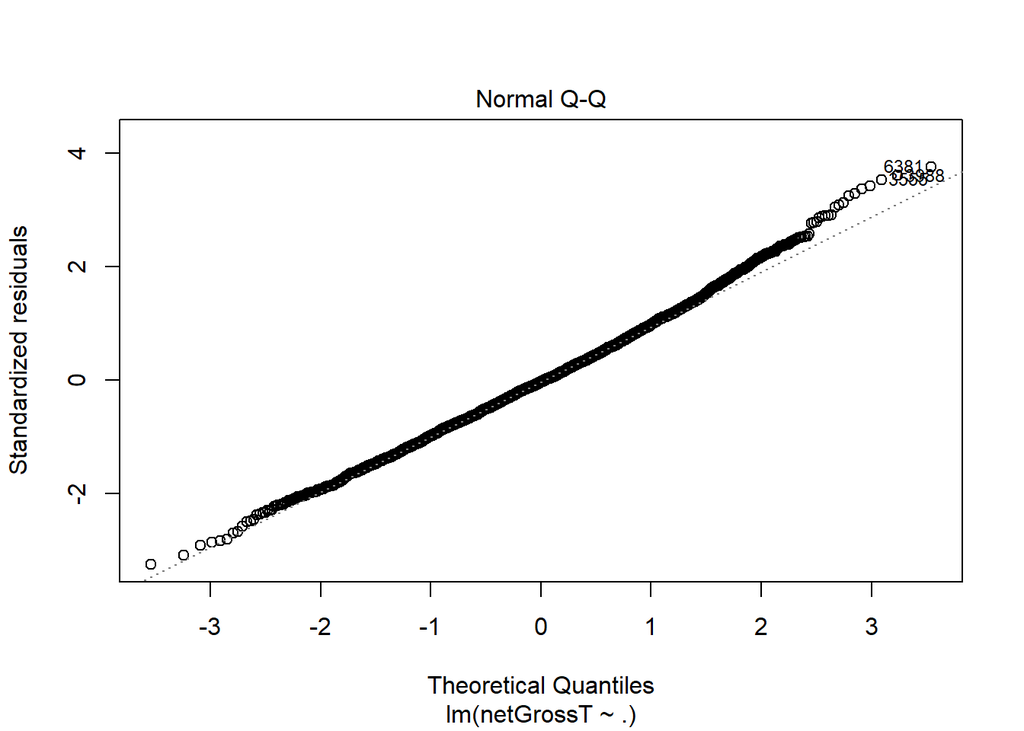

```r
plot(fit.T,2)
```

```r
summary(fit.T)
```

```
##
## Call:
## lm(formula = netGrossT ~ ., data = fit.dataT)
##
## Residuals:
##      Min       1Q   Median       3Q      Max
## -180.116  -38.091   -1.635   34.691  210.054
##
## Coefficients:
##                 Estimate Std. Error t value             Pr(>|t|)
## (Intercept)     -1.12213   15.42025  -0.073              0.94200
## countryFrance    0.42541   14.30176   0.030              0.97627
## countryUK      -16.03435   11.45064  -1.400              0.16155
## countryUSA      -0.22074   10.50473  -0.021              0.98324
## countryOther   -14.75771   11.53925  -1.279              0.20105
## genreAdventure  11.26314    5.28077   2.133              0.03303 *
## genreAnimation  31.37690    6.66656   4.707  0.00000265686952636 ***
## genreBiography  -3.88476    6.06205  -0.641              0.52169
## genreComedy      4.43876    3.35266   1.324              0.18564
## genreCrime      -9.31965    5.21727  -1.786              0.07417 .
## genreDrama      -4.30357    4.04884  -1.063              0.28792
## genreHorror     24.94988    5.40387   4.617  0.00000409058541591 ***
## genreOther      -1.55469    8.60542  -0.181              0.85665
## ratingNC-17    -53.50268   33.47573  -1.598              0.11011
## ratingPG        -3.80504    7.75915  -0.490              0.62390
## ratingPG-13      0.59285    8.12361   0.073              0.94183
## ratingR        -15.15562    8.14457  -1.861              0.06289 .
## ratingUNRATED  -43.81085   15.37884  -2.849              0.00442 **
## runtime          0.66783    0.08292   8.054  0.00000000000000123 ***
## budgetT          3.11987    0.22029  14.163 < 0.0000000000000002 ***
## ---
## Signif. codes:  0 '***' 0.001 '**' 0.01 '*' 0.05 '.' 0.1 ' ' 1
##
## Residual standard error: 55.93 on 2487 degrees of freedom
##   (4313 observations deleted due to missingness)
## Multiple R-squared:  0.267,  Adjusted R-squared:  0.2614
## F-statistic: 47.67 on 19 and 2487 DF,  p-value: < 0.00000000000000022
```